# Large panels and compressed regressions

Test whether small regression summaries preserve a large longitudinal experiment.

These simulations follow [Large Scale Longitudinal Experiments](https://arxiv.org/abs/2410.09952) by Apoorva Lal, Alexander Fischer, and Matthew Wardrop, with [public code](https://github.com/py-econometrics/panel-at-scale-code). The simulations test regression compression under several panel structures; storage and distributed estimation are outside this example.

## 1 Scientific question

Suppose raw longitudinal data are too large to centralize. A site can transmit small regression summaries instead. A simulation should test whether those summaries preserve the treatment-effect information under trends, serial dependence, and heterogeneous effects.

```python
import matplotlib.pyplot as plt
import numpy as np

from pypanelsim import designs
```

## 2 Main panel design

The untreated outcome contains unit effects, time effects, unit-specific linear trends, and AR(1) error. One cohort adopts treatment. The effect path can be concave or another configured profile, with optional unit heterogeneity.

```python
config = designs.RegressionCompressionConfig(
    n_units=800,
    n_periods=35,
    adoption_period=15,
    n_treated=320,
    effect_profile="concave",
    max_effect=1.0,
    heterogeneous_effects=True,
)

panel = designs.regression_compression(config=config, seed=42)
print(panel.shape)
print(round(panel.true_att, 3))
```

```
(800, 35)
0.345
```

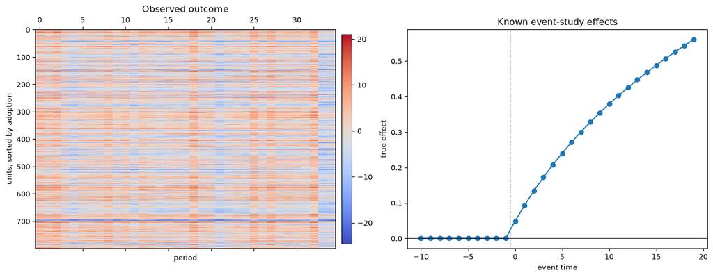

Figure 1: Observed outcomes and known event-time effects in the regression-compression design.

```python
order = np.argsort(panel.adoption_times, kind="stable")
event_truth = panel.truth.event_study(event_times=range(-10, 20))

figure, axes = plt.subplots(1, 2, figsize=(13, 5), constrained_layout=True)
outcome_image = axes[0].matshow(
    panel.outcome[order],
    aspect="auto",
    cmap="coolwarm",
)
axes[0].set_xlabel("period")
axes[0].set_ylabel("units, sorted by adoption")
axes[0].set_title("Observed outcome")
figure.colorbar(outcome_image, ax=axes[0], fraction=0.035, pad=0.02)

axes[1].plot(
    event_truth["event_time"],
    event_truth["effect"],
    marker="o",
)
axes[1].axhline(0.0, color="black", linewidth=0.7)
axes[1].axvline(-0.5, color="grey", linestyle=":", linewidth=0.8)
axes[1].set_xlabel("event time")
axes[1].set_ylabel("true effect")
axes[1].set_title("Known event-study effects")
plt.show()
```

## 3 A minimal compressed summary

For a regression $y=X\beta+u$, a site can summarize its data with $X'X$, $X'y$, $y'y$, and the observation count. Sites can add these terms without sharing rows.

The example below uses treatment, a post indicator, and their interaction. It is deliberately small; an applied design would add its required fixed-effect or basis representation.

```python
columns = panel.as_long_dict()
y = columns["outcome"]

post = (columns["time"] >= config.adoption_period).astype(float)
treated_unit = np.repeat(panel.ever_treated.astype(float), panel.n_periods)
x = np.column_stack(
    (
        np.ones(y.size),
        treated_unit,
        post,
        treated_unit * post,
    )
)

summary = {
    "n": y.size,
    "xtx": x.T @ x,
    "xty": x.T @ y,
    "yty": float(y @ y),
}

beta_from_summary = np.linalg.solve(summary["xtx"], summary["xty"])
beta_from_rows = np.linalg.lstsq(x, y, rcond=None)[0]

print(np.allclose(beta_from_summary, beta_from_rows))
print(np.round(beta_from_summary, 3))
```

```
True
[ 0.13   0.133 -0.591  0.261]
```

This equality is algebraic for the stated regression. It does not show that the interaction coefficient equals the desired dynamic-effect estimand. Compression and causal identification are separate questions.

## 4 Combine summaries across sites

```python
site_ids = np.array_split(np.arange(panel.n_units), 4)
site_summaries = []

for site_units in site_ids:
    rows = np.isin(columns["unit"], site_units)
    x_site = x[rows]
    y_site = y[rows]
    site_summaries.append((x_site.T @ x_site, x_site.T @ y_site))

pooled_xtx = sum(item[0] for item in site_summaries)
pooled_xty = sum(item[1] for item in site_summaries)
pooled_beta = np.linalg.solve(pooled_xtx, pooled_xty)

print(np.allclose(pooled_beta, beta_from_rows))
```

```
True
```

The partition has no effect because the summaries are additive.

## 5 Anscombe-style stress tests

The Anscombe family changes panel structure while preserving selected low-order summaries. It asks whether an analysis that sees only those summaries misses a scientifically important difference.

```python
print(designs.available_anscombe_designs())

anscombe_config = designs.AnscombePanelConfig(
    n_units=400,
    n_periods=20,
)

for name in designs.available_anscombe_designs():
    draw = designs.anscombe(name, config=anscombe_config, seed=17)
    print(name, draw.shape, round(draw.true_att, 3))
```

```
('zero', 'unit', 'time', 'cohort_time')
zero (400, 20) 0.0
unit (400, 20) -0.006
time (400, 20) -0.0
cohort_time (400, 20) -0.0
```

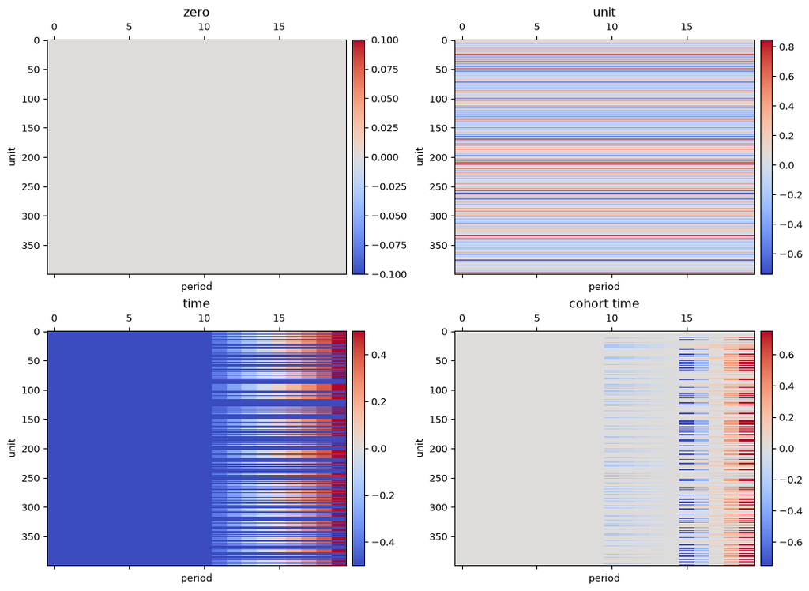

Figure 2: Treatment effects for the four Anscombe-style panel variants.

```python
figure, axes = plt.subplots(2, 2, figsize=(11, 8), constrained_layout=True)
for axis, name in zip(
    axes.ravel(),
    designs.available_anscombe_designs(),
    strict=True,
):
    draw = designs.anscombe(name, config=anscombe_config, seed=17)
    image = axis.matshow(draw.effect_surface, aspect="auto", cmap="coolwarm")
    axis.set_title(name.replace("_", " "))
    axis.set_xlabel("period")
    axis.set_ylabel("unit")
    figure.colorbar(image, ax=axis, fraction=0.04, pad=0.02)
plt.show()
```

The four variants are `zero`, `unit`, `time`, and `cohort_time`. They locate heterogeneity at different levels.

## 6 What to report

A compression experiment should report both layers:

- the causal design: assignment, untreated outcomes, potential effects, and target;
- the transmitted summary: regressors, sufficient statistics, grouping, and numeric precision.

A small communication cost is not useful if the summary corresponds to the wrong regression or the regression corresponds to the wrong causal target.